# HW 6 Solutions

**Grading for questions 1 - 11:** Answers may vary slightly for some questions, which is ok. Students can receive full credit as long as their answer seems reasonable.

## Question 1 (2 pts)

Dengue is a widespread disease, and early diagnosis is important for treatment and disease management. Gold-standard tests are limited and time-consuming, and rapid tests are not available in all settings. A prediction model provides an alternative to tests which may not be available.

## Question 2 (2 pts)

The goal of the study is to construct a classifier to predict dengue in pediatric patients using commonly-available diagnostic measurements, and assess its performance.

## Question 3 (1 pt)

5729 children

## Question 4 (2 pts)

Inclusion: fever at presentation, less than 72 hours of symptoms, doctor thinks illness could be dengue, aged between 1 and 15 years, parent/guardian has a mobile phone, and parent/guardian provides written consent.

Exclusion: doctor thinks the patient won’t follow up, or thinks another diagnosis is more likely than dengue

## Question 5 (2 pts)

Explanatory variables: Age, sex, BMI, day of illness, temperature, vomiting, abdominal pain, skin bleeding, mucosal bleeding, flush, hepatomegaly, rash, infection, WBC, PLT, HCT, ALB, AST, CK

They also recorded whether the patient had dengue from a lab test, and the results of a rapid antigen test

## Question 6 (2 pts)

Logistic regression was used to predict dengue from the available clinical measurements, and techniques like stepwise selection were used to choose variables. Performance was assessed using AUC and confusion matrix metrics (accuracy, sensitivity, specificity, etc.). Performance was also compared to models built using decision trees and random forests.

## Question 7 (2 pts)

The researchers used backward stepwise selection with AIC, and stability selection.

## Question 8 (1 pt)

0.333

## Question 9 (2 pts)

Age, WBC, PLT

## Question 10 (2 pts)

Sensitivity: 74.8%, Specificity: 76.3%

## Question 11 (1 pt)

0.829

## Question 12

### (a) (2 pts)

```r
table(dengue$RapidTest, dengue$Dengue)
```

```
##
##               0    1
##   negative 3990  503
##   positive   33 1194
```

**Grading:** No points if code missing

### (b) (4 pts)

Accuracy = (3990 + 1194)/5720 = 0.91

Sensitivity = 1194/(1194 + 503) = 0.70

Specificity = 3990/(3990 + 33) = 0.99

PPV = 1194/(1194 + 33) = 0.97

**Grading:** 1 pt for each prediction metric

## Question 13

### (a) (2 pts)

```r
m1 <- glm(Dengue ~ Age + WBC + PLT, data = dengue, family = binomial)
```

### (b) (2 pts)

```r
table(Prediction = m1$fitted.values > 0.33,
      Truth = dengue$Dengue)
```

```
##           Truth
## Prediction    0    1
##      FALSE 3069  430
##      TRUE   954 1267
```

**Grading:** Lose 1 pt for using the wrong threshold. No points if the confusion matrix doesn’t compare the predictions with Dengue, or if the confusion matrix uses the wrong predictions.

### (c) (4 pts)

Accuracy = (3069 + 1267)/5720 = 0.76

Sensitivity = 1267/(1267 + 430) = 0.75

Specificity = 3069/(3069 + 954) = 0.76

PPV = 1267/(1267 + 954) = 0.57

Yes, these are similar to the values in the original paper.

**Grading:** 1 pt for each prediction metric.

### (d) (2 pts)

Sensitivity is slightly higher (if we changed the threshold, we would change the sensitivity value). The other metrics are lower than for the rapid test.

### (e) (2 pts)

```r
library(ROCR)
pred <- prediction(m1$fitted.values, dengue$Dengue)
perf <- performance(pred,"tpr","fpr")
performance(pred, "auc")@y.values
```

```
## [[1]]
## [1] 0.8287245
```

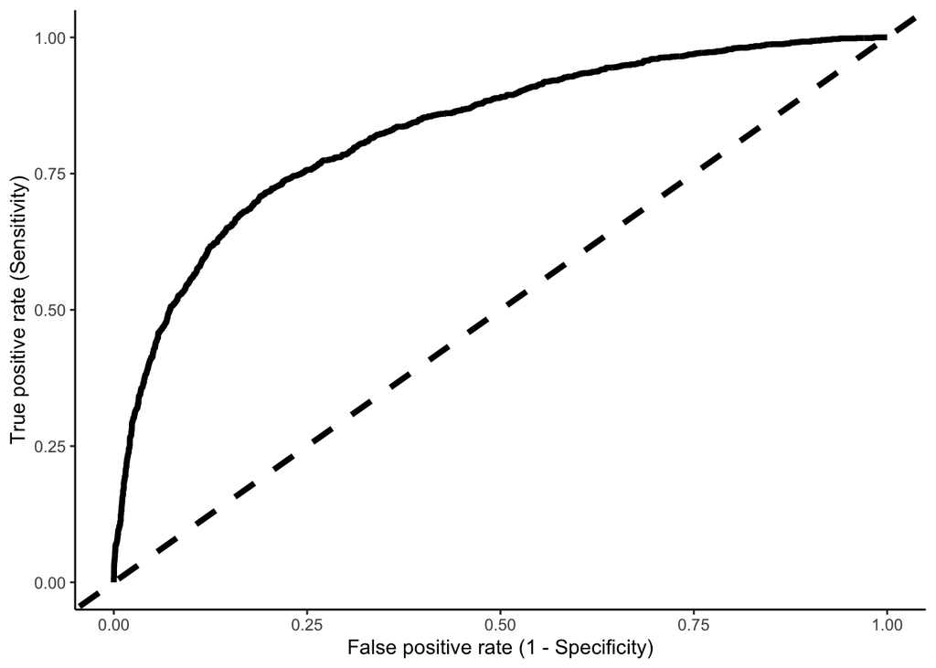

```r
data.frame(fpr = perf@x.values[[1]],
tpr = perf@y.values[[1]]) %>%
  ggplot(aes(x = fpr, y = tpr)) +
  geom_line(lwd=1.5) +
  geom_abline(slope = 1, intercept = 0, lty = 2,
  lwd = 1.5) +
  labs(x = "False positive rate (1 - Specificity)",
  y = "True positive rate (Sensitivity)") +
  theme_classic()
```

The AUC is about 0.83, which is similar to the value in the original paper.

**Grading:** 1 pt for ROC curve, 1 pt for AUC

## Question 14

### (a) (3 pts)

```r
library(MASS)
m0 <- glm(Dengue ~ 1, family = binomial, data = dengue)
forward_aic <- stepAIC(m0, scope = ~ Sex + Age + DiseaseDay + Vomiting + Abdominal + Temperature + BMI + WBC + HCT + PLT, trace = 0, direction = "forward")
summary(forward_aic)
```

```
##
## Call:
## glm(formula = Dengue ~ WBC + Age + PLT + BMI + Temperature +
##     Vomiting + DiseaseDay, family = binomial, data = dengue)
##
## Deviance Residuals:
##     Min       1Q   Median       3Q      Max
## -2.1943  -0.7238  -0.3553   0.7067   3.5828
##
## Coefficients:
##               Estimate Std. Error z value Pr(>|z|)
## (Intercept) -9.3075066  1.7907414  -5.198 2.02e-07 ***
## WBC         -0.2788864  0.0145023 -19.231  < 2e-16 ***
## Age          0.1270005  0.0102446  12.397  < 2e-16 ***
## PLT         -0.0058158  0.0006235  -9.327  < 2e-16 ***
## BMI          0.0701594  0.0111688   6.282 3.35e-10 ***
## Temperature  0.2548779  0.0457873   5.567 2.60e-08 ***
## Vomiting     0.4045367  0.0709320   5.703 1.18e-08 ***
## DiseaseDay  -0.1619727  0.0495955  -3.266  0.00109 **
## ---
## Signif. codes:  0 '***' 0.001 '**' 0.01 '*' 0.05 '.' 0.1 ' ' 1
##
## (Dispersion parameter for binomial family taken to be 1)
##
##     Null deviance: 6955.8  on 5719  degrees of freedom
## Residual deviance: 5082.6  on 5712  degrees of freedom
## AIC: 5098.6
##
## Number of Fisher Scoring iterations: 6
```

The variables chosen are WBC, Age, PLT, BMI, Temperature, Vomiting, and DiseaseDay.

**Grading:** No points if no code shown. Lose 1 pt if they don’t report the selected variables. Lose 1 pt if their scope in the stepAIC function is incorrect.

### (b) (3 pts)

```r
pred <- prediction(forward_aic$fitted.values, dengue$Dengue)
perf <- performance(pred,"tpr","fpr")
performance(pred, "auc")@y.values
```

```
## [[1]]
## [1] 0.837498
```

The AUC for the model chosen by stepwise selection is about 84%, which is very similar to the smaller model considered in question 13.

**Grading:** No points if code not shown. Lose 2 pts if missing AUC. Lose 1 pt if no comparison to question 13.

### (c) (2 pts)

The model in question 13 is much simpler to use and interpret, but has almost the same predictive performance. So we prefer the model in question 13.